# Projeto - Ciência de Dados I

Costa,Pamela; Muniz,Isabella; Bini,Aline

11/06/2021

———<>———

# PROJETO FINAL: CIENCIA DE DADOS I - FASE 1

———<>———

1. INTRODUÇÃO:

Definindo o Problema de Negócio: Estudar bases de dados relacionadas a passagem de pacientes por um Hospital, entendendo o comportamento e os fatores relevantes.

2. OBJETIVO:

Descrever o comportamento dos pacientes que frequentam um Hospital a partir de bases de dados relacionada a passagem, analisar todo o contexto de forma descritiva levantando insights e observações.

3. BASE DE DADOS:

Baseado em dados anonimizados da passagem de um paciente em um grande hospital, o dataset “dataset_2uz.csv” contém 2185 observações e 10 variáveis. Complementamos a análise com um dataset secundário “dataset_raw.xlsx - dataset_raw_vA.cs” contendo dados de localidade dos pacientes que tiveram passagens e tempo de permanencia no hospital, contendo as mesmas 2185 observações e 3 variáveis, a granularidade em ambas a base é a passagem do paciente pelo Hospital.

4. PIPELINE DO PROJETO:

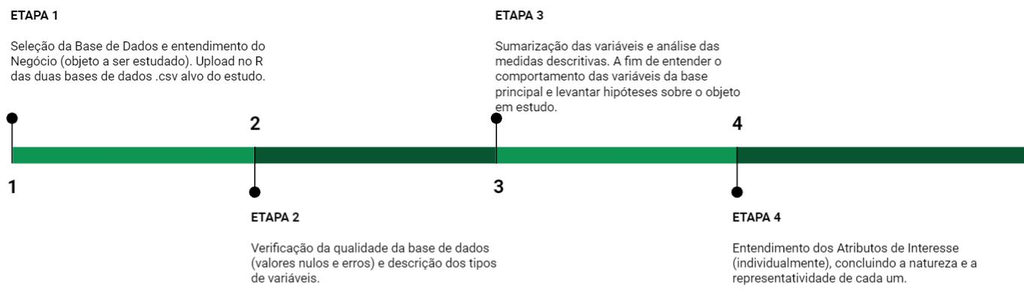

Figura.01: Pipeline da Análise dos Dados

———<>———

5. DESENVOLVIMENTO:

Definindo o diretório de trabalho e o ambiente de produção.)

```r
getwd()
```

```
## [1] "C:/Users/pamgc/OneDrive/Documentos/Base de Dados"
```

```r
#setwd()
function (...)
.rs.callAs(name, hook, original, ...)
```

```
## function (...)
## .rs.callAs(name, hook, original, ...)
```

———<>———

Carregar o dataset

———<>———

Como normalmente ainda não se tem conhecimento prévio sobre o que cada atributo significa para o problema de negócio, vamos dar preferência para importá-los sem nenhum tipo de conversão automática (stringsAsFactors = FALSE). Garanta também a informação sobre se o dataset possui ou não cabeçalho (header = TRUE/FALSE).

DATASET PRINCIPAL

```r
df <- read.csv("dataset_2uz.csv",
               header = TRUE,
               sep = ";",
               encoding = "latin1",
               stringsAsFactors = FALSE)
View(df)

str(df)
```

```
## 'data.frame':    2185 obs. of  10 variables:
##  $ sexo            : int  1 2 2 2 2 2 2 2 2 2 ...
##  $ codcid          : chr  "D412" "S527" "G579" "W949" ...
##  $ grupodiagnostico: chr  "CARDIOLOGIA" "NÃO INFORMADO" "OUTROS" "OTORRINOLARINGOLOGIA E CIRURGIA BUCO-MAXILO" ...
##  $ idade           : int  65 18 20 22 23 23 24 26 27 29 ...
##  $ diadasemana     : int  4 7 7 4 6 4 7 5 5 5 ...
##  $ dia             : int  24 22 24 8 15 3 5 26 28 10 ...
##  $ mes             : int  8 12 7 3 6 10 4 8 4 1 ...
##  $ ano             : int  2011 2001 2004 2006 2007 2007 2008 2010 2011 2013 ...
##  $ season          : int  2 4 2 4 1 3 1 2 1 4 ...
##  $ internacao      : int  0 0 0 0 0 0 0 0 0 0 ...
```

```r
head(df)
```

```
##   sexo codcid                            grupodiagnostico idade diadasemana dia
## 1    1   D412                                 CARDIOLOGIA    65           4  24
## 2    2   S527                               NÃO INFORMADO    18           7  22
## 3    2   G579                                      OUTROS    20           7  24
## 4    2   W949 OTORRINOLARINGOLOGIA E CIRURGIA BUCO-MAXILO    22           4   8
## 5    2   Y133 OTORRINOLARINGOLOGIA E CIRURGIA BUCO-MAXILO    23           6  15
## 6    2   F442            DERMATOLOGIA E CIRURGIA PLÁSTICA    23           4   3
##   mes  ano season internacao
## 1   8 2011      2          0
## 2  12 2001      4          0
## 3   7 2004      2          0
## 4   3 2006      4          0
## 5   6 2007      1          0
## 6  10 2007      3          0
```

DATASET COMPLEMENTAR

```r
dfC <- read.csv("dataset_raw.xlsx - dataset_raw_vA.csv",
               header = TRUE,
               sep = ",",
               encoding = "latin1",
               stringsAsFactors = FALSE)
View(dfC)

str(dfC)
```

```
## 'data.frame':    2185 obs. of  3 variables:
##  $ cidade           : chr  "SAO PAULO" "COTIA" "SAO PAULO" "SAO PAULO" ...
##  $ estado           : chr  "SP" "SP" "SP" "SP" ...
##  $ permanencia.dias.: int  1 0 0 0 1 1 0 0 0 0 ...
```

```r
head(dfC)
```

```
##      cidade estado permanencia.dias.
## 1 SAO PAULO     SP                 1
## 2     COTIA     SP                 0
## 3 SAO PAULO     SP                 0
## 4 SAO PAULO     SP                 0
## 5 SAO PAULO     SP                 1
## 6 SAO PAULO     SP                 1
```

———<>———

Data Wrangling

———<>———

Verificar a existência de dados nulos.

Para isso vamos usar a função “is.na”: retorna “TRUE” se houver valor nulo (“na”) retorna “FALSE” se não houver.

```r
#is.na(df) # (!) difícil constatação (!)
```

Vamos aplicar a função “sum()” em conjunto com a função “is.na()” para retornar a soma dos casos TRUE (TRUE tem valor 1 e FALSE tem valor 0).

```r
sum(is.na(dfC)) #o resultado igual a "0" (zero), confirma-se que não temos valores nulos no dataset.
```

```
## [1] 0
```

```r
sum(is.na(df)) #o resultado igual a "0" (zero), confirma-se que não temos valores nulos no dataset.
```

```
## [1] 0
```

Função “summary()” verifica algumas medidas descritivas, possibilitando assim as primeiras inferências e algumas conclusões sobre os atributos.

OBSERVAÇÕES:

```r
summary(df)
```

```
##       sexo          codcid          grupodiagnostico       idade
##  Min.   :1.000   Length:2185        Length:2185        Min.   : 9.00
##  1st Qu.:1.000   Class :character   Class :character   1st Qu.:42.00
##  Median :2.000   Mode  :character   Mode  :character   Median :56.00
##  Mean   :1.532                                         Mean   :55.68
##  3rd Qu.:2.000                                         3rd Qu.:71.00
##  Max.   :2.000                                         Max.   :94.00
##   diadasemana         dia             mes              ano
##  Min.   :1.000   Min.   : 1.00   Min.   : 1.000   Min.   :2000
##  1st Qu.:3.000   1st Qu.: 8.00   1st Qu.: 3.000   1st Qu.:2006
##  Median :4.000   Median :16.00   Median : 6.000   Median :2010
##  Mean   :4.058   Mean   :15.69   Mean   : 6.265   Mean   :2009
##  3rd Qu.:6.000   3rd Qu.:23.00   3rd Qu.: 9.000   3rd Qu.:2013
##  Max.   :7.000   Max.   :31.00   Max.   :12.000   Max.   :2016
##      season        internacao
##  Min.   :1.000   Min.   :0.00000
##  1st Qu.:1.000   1st Qu.:0.00000
##  Median :2.000   Median :0.00000
##  Mean   :2.415   Mean   :0.08009
##  3rd Qu.:3.000   3rd Qu.:0.00000
##  Max.   :4.000   Max.   :1.00000
```

```r
summary(dfC)
```

```
##     cidade             estado          permanencia.dias.
##  Length:2185        Length:2185        Min.   :0.0000
##  Class :character   Class :character   1st Qu.:0.0000
##  Mode  :character   Mode  :character   Median :0.0000
##                                        Mean   :0.3753
##                                        3rd Qu.:1.0000
##                                        Max.   :1.0000
```

Entendimento dos Atributos de Interesse

(Sexo)

OBSERVAÇÕES: Análisando os valores de frequencia e o gráfico gerado vemos que o sexo masculino é mais frequente nos atendimento do que o sexo feminino, representando 53,18% das observações.

Tipo de Variável: Qualitativa Nominal

```r
#Frequencia absoluta
table(df$sexo)
```

```
##
##    1    2
## 1023 1162
```

```r
#Frequencia relativa
prop.table(table(df$sexo))
```

```
##
##         1         2
## 0.4681922 0.5318078
```

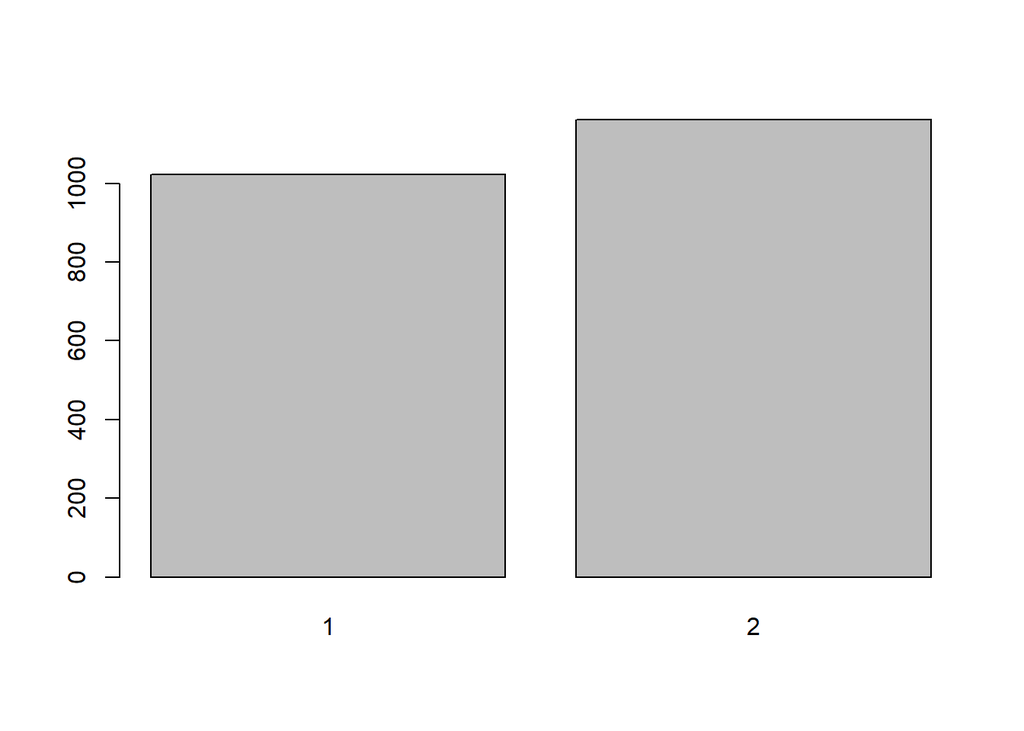

```r
# Bar Plots

barplot(table(df$sexo))
```

(codcid)

OBSERVAÇÕES: Analisando a tabela de frequência o gráfico plotado vemos que o código do CID é um fator muito disperso, ou seja, possui valores quase que exclusivos por observação

Tipo de Variável: Qualitativa Nominal

```r
#Frequencia absoluta
table(df$codcid)
```

```
##
## A000 A021 A029 A033 A041 A044 A047 A063 A072 A151 A158 A187 A190 A203 A210 A228
##    1    1    1    1    2    1    1    1    1    1    1    1    1    1    1    1
## A232 A251 A304  A38 A400 A401 A420 A427 A438 A484 A488 A492 A493 A501 A507 A509
##    1    1    1    3    1    1    1    1    1    2    1    1    1    1    1    1
## A512 A544 A561 A564  A58 A630 A664 A666 A680 A689 A692 A698 A699 A749 A801 A809
##    1    1    2    1    1    1    1    1    1    1    1    1    1    1    1    1
## A811 A831 A838 A849 A922 A923  A94 A951 A960  A99 B004 B012 B027 B052 B060 B159
##    1    1    1    1    1    1    1    2    1    1    1    2    1    1    1    1
## B161 B171 B172 B180 B201 B212 B219 B220 B232 B261 B331 B333 B338 B343 B356 B363
##    2    2    1    1    1    2    1    1    1    1    2    1    1    1    1    1
## B376 B383 B409 B420 B432 B442 B464 B468 B480 B488 B561 B569 B588 B680 B700 B743
##    1    1    1    1    1    1    1    1    1    1    1    1    1    1    1    1
## B813 B829 B832 B852 B854  B86 B871 B873 B874 B882 B888 B908 B950 B972 B973 B978
##    1    1    1    1    1    1    1    1    1    1    2    1    1    1    2    1
## C048 C049 C051 C060 C081 C091 C102 C110 C130 C138 C148 C153 C154 C161 C169 C185
##    1    1    1    1    1    1    2    1    1    1    3    1    1    1    1    1
##  C20 C254 C258 C268 C300 C320 C321 C323  C33 C399 C418 C419 C435 C441 C446 C459
##    1    1    1    1    2    1    1    1    1    1    1    2    2    1    2    1
## C470 C479 C498 C499 C500 C504 C511 C541 C542 C549  C55 C608 C621  C66 C672 C676
##    1    1    1    1    1    1    1    1    1    1    1    1    2    1    1    1
## C681 C688 C694 C699 C700 C709 C720 C722 C725 C741 C760 C761 C762 C770 C774 C778
##    1    1    2    1    1    1    2    1    1    1    1    1    1    1    1    1
## C785 C788 C792 C797  C80 C810 C822 C832 C842 C881 C929 C930 C960 C961  C97 D023
##    1    1    1    1    1    1    1    1    1    1    2    2    1    1    1    1
## D032 D039 D041 D042 D048 D059 D069 D075 D076 D092 D102 D106 D109 D117 D119 D124
##    1    1    1    1    1    1    1    1    1    1    1    1    1    1    1    1
## D125 D134 D136 D142 D150 D160 D166 D168 D171 D190 D197 D201 D212 D213 D222 D226
##    1    1    1    1    1    2    1    1    1    1    1    1    1    1    1    1
## D250 D267 D300 D302 D311 D330 D332 D353 D355 D359 D361 D370 D371 D385 D392 D410
##    1    1    1    1    1    2    1    1    1    1    1    1    1    1    1    1
## D411 D412 D414 D437 D449 D467 D482 D500 D509 D530 D550 D552 D562 D564 D572 D581
##    3    1    2    1    1    1    1    1    1    1    1    1    1    1    1    2
## D588 D596 D611 D692 D696 D731 D733 D734 D751  D77 D801 D823 D824 D832 D848 D892
##    1    1    1    1    1    2    1    1    1    1    1    1    1    1    1    1
## D899 E011 E031 E032 E039 E049 E050 E052 E060 E062 E064 E118 E120 E121 E142 E144
##    1    1    1    1    1    1    1    1    2    1    1    1    1    1    1    1
## E164 E212 E215 E228 E232 E237 E261 E271 E290 E308 E320 E329 E441  E45 E500 E504
##    1    1    1    1    1    1    1    2    1    1    1    1    1    1    1    1
## E506 E507 E509 E550 E560 E561  E58  E60 E613 E616 E640 E642 E648 E661 E702 E703
```

[output cut: 194 more lines]

```
##    2    1    1    1    1    1    1    2    1    1    1    1    2    1    1    1
## Z049 Z082 Z087 Z090 Z094 Z097 Z115 Z119 Z120 Z124 Z136 Z203 Z207 Z222 Z229 Z238
##    1    1    1    1    1    2    2    1    1    1    1    1    1    1    1    1
## Z250 Z251 Z271 Z312 Z318 Z319  Z33 Z348 Z353 Z355 Z361 Z375 Z379 Z387 Z409 Z435
##    1    1    1    1    1    1    1    1    1    1    1    1    1    1    1    1
## Z442 Z443 Z459 Z463 Z468 Z469 Z470 Z491 Z507 Z515 Z516 Z520 Z521 Z527 Z539 Z540
##    1    1    1    1    1    1    1    1    1    2    1    1    1    1    1    1
## Z543 Z544 Z547 Z551 Z553 Z559 Z562 Z563 Z584 Z603 Z614 Z617 Z619 Z624 Z631 Z633
##    1    1    1    1    1    1    1    1    1    2    1    2    1    1    1    1
## Z655 Z700 Z712 Z728 Z729 Z730 Z735 Z736 Z754 Z759 Z763 Z768 Z801 Z805 Z809 Z826
##    1    1    1    1    1    1    1    1    1    1    1    1    2    1    1    1
## Z827 Z828 Z848 Z860 Z861 Z878 Z883 Z892 Z896 Z902 Z903 Z905 Z906 Z921 Z922 Z928
##    1    1    1    1    1    1    1    1    1    1    2    1    1    1    1    1
## Z930
##    1
```

```r
#Frequencia relativa
prop.table(table(df$codcid))
```

```
##
##         A000         A021         A029         A033         A041         A044
## 0.0004576659 0.0004576659 0.0004576659 0.0004576659 0.0009153318 0.0004576659
##         A047         A063         A072         A151         A158         A187
## 0.0004576659 0.0004576659 0.0004576659 0.0004576659 0.0004576659 0.0004576659
##         A190         A203         A210         A228         A232         A251
## 0.0004576659 0.0004576659 0.0004576659 0.0004576659 0.0004576659 0.0004576659
##         A304          A38         A400         A401         A420         A427
## 0.0004576659 0.0013729977 0.0004576659 0.0004576659 0.0004576659 0.0004576659
##         A438         A484         A488         A492         A493         A501
## 0.0004576659 0.0009153318 0.0004576659 0.0004576659 0.0004576659 0.0004576659
##         A507         A509         A512         A544         A561         A564
## 0.0004576659 0.0004576659 0.0004576659 0.0004576659 0.0009153318 0.0004576659
##          A58         A630         A664         A666         A680         A689
## 0.0004576659 0.0004576659 0.0004576659 0.0004576659 0.0004576659 0.0004576659
##         A692         A698         A699         A749         A801         A809
## 0.0004576659 0.0004576659 0.0004576659 0.0004576659 0.0004576659 0.0004576659
##         A811         A831         A838         A849         A922         A923
## 0.0004576659 0.0004576659 0.0004576659 0.0004576659 0.0004576659 0.0004576659
##          A94         A951         A960          A99         B004         B012
## 0.0004576659 0.0009153318 0.0004576659 0.0004576659 0.0004576659 0.0009153318
##         B027         B052         B060         B159         B161         B171
## 0.0004576659 0.0004576659 0.0004576659 0.0004576659 0.0009153318 0.0009153318
##         B172         B180         B201         B212         B219         B220
## 0.0004576659 0.0004576659 0.0004576659 0.0009153318 0.0004576659 0.0004576659
##         B232         B261         B331         B333         B338         B343
## 0.0004576659 0.0004576659 0.0009153318 0.0004576659 0.0004576659 0.0004576659
##         B356         B363         B376         B383         B409         B420
## 0.0004576659 0.0004576659 0.0004576659 0.0004576659 0.0004576659 0.0004576659
##         B432         B442         B464         B468         B480         B488
## 0.0004576659 0.0004576659 0.0004576659 0.0004576659 0.0004576659 0.0004576659
##         B561         B569         B588         B680         B700         B743
## 0.0004576659 0.0004576659 0.0004576659 0.0004576659 0.0004576659 0.0004576659
##         B813         B829         B832         B852         B854          B86
## 0.0004576659 0.0004576659 0.0004576659 0.0004576659 0.0004576659 0.0004576659
##         B871         B873         B874         B882         B888         B908
## 0.0004576659 0.0004576659 0.0004576659 0.0004576659 0.0009153318 0.0004576659
##         B950         B972         B973         B978         C048         C049
## 0.0004576659 0.0004576659 0.0009153318 0.0004576659 0.0004576659 0.0004576659
##         C051         C060         C081         C091         C102         C110
```

[output cut: 604 more lines]

```
## 0.0004576659 0.0004576659 0.0004576659 0.0009153318 0.0004576659 0.0009153318
##         Z619         Z624         Z631         Z633         Z655         Z700
## 0.0004576659 0.0004576659 0.0004576659 0.0004576659 0.0004576659 0.0004576659
##         Z712         Z728         Z729         Z730         Z735         Z736
## 0.0004576659 0.0004576659 0.0004576659 0.0004576659 0.0004576659 0.0004576659
##         Z754         Z759         Z763         Z768         Z801         Z805
## 0.0004576659 0.0004576659 0.0004576659 0.0004576659 0.0009153318 0.0004576659
##         Z809         Z826         Z827         Z828         Z848         Z860
## 0.0004576659 0.0004576659 0.0004576659 0.0004576659 0.0004576659 0.0004576659
##         Z861         Z878         Z883         Z892         Z896         Z902
## 0.0004576659 0.0004576659 0.0004576659 0.0004576659 0.0004576659 0.0004576659
##         Z903         Z905         Z906         Z921         Z922         Z928
## 0.0009153318 0.0004576659 0.0004576659 0.0004576659 0.0004576659 0.0004576659
##         Z930
## 0.0004576659
```

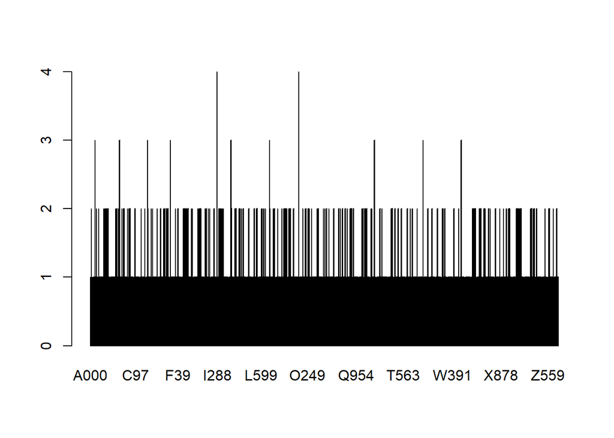

```r
# Bar Plots

barplot(table(df$codcid))
```

(grupodiagnostico)

OBSERVAÇÕES: Analisando a tabela de frequencia e o gráfico plotado vemos que temos quatro classificações de diagnósticos com maior frequencia, sendo que dois a uma classificação genérica, uma como “Não informado” e outra como “outros”.

Tipo de Variável: Qualitativa Nominal

```r
#Frequencia absoluta
table(df$grupodiagnostico)
```

```
##
##                                                     CARDIOLOGIA
##                                                             129
##                                             CIRURGIA BARIÁTRICA
##                                                              15
##                                       CIRURGIA CABEÇA E PESCOÇO
##                                                               7
##                                DERMATOLOGIA E CIRURGIA PLÁSTICA
##                                                              97
##                                                       ENDÓCRINO
##                                                              30
## GASTROENTEROLOGIA, GASTROCIRURGIA, PROCTOLOGIA E CIRURGIA GERAL
##                                                             257
##                                                     GINECOLOGIA
##                                                              49
##                                                     HEMATOLOGIA
##                                                              98
##                                                      MASTOLOGIA
##                                                              15
##                                                     MATERNIDADE
##                                                              38
##                                           MOLÉSTIAS INFECCIOSAS
##                                                              57
##                                                       MORADORES
##                                                              14
##                                                   NÃO INFORMADO
##                                                             327
##                                           NEFROLOGIA E UROLOGIA
##                                                             132
##                                                      NEUROLOGIA
##                                                              89
##                                                    OFTALMOLOGIA
##                                                              90
##                                                       ONCOLOGIA
##                                                              99
##                     OTORRINOLARINGOLOGIA E CIRURGIA BUCO-MAXILO
##                                                              72
##                                                          OUTROS
##                                                             233
##                                 PNEUMOLOGIA E CIRURGIA TORÁCICA
##                                                             107
##                                        REUMATOLOGIA E ORTOPEDIA
##                                                             198
##                                                    SAÚDE MENTAL
##                                                               9
##                                                    TRANSPLANTES
##                                                               2
##                                                        VASCULAR
##                                                              21
```

```r
#Frequencia relativa
prop.table(table(df$grupodiagnostico))
```

```
##
##                                                     CARDIOLOGIA
##                                                    0.0590389016
##                                             CIRURGIA BARIÁTRICA
##                                                    0.0068649886
##                                       CIRURGIA CABEÇA E PESCOÇO
##                                                    0.0032036613
##                                DERMATOLOGIA E CIRURGIA PLÁSTICA
##                                                    0.0443935927
##                                                       ENDÓCRINO
##                                                    0.0137299771
## GASTROENTEROLOGIA, GASTROCIRURGIA, PROCTOLOGIA E CIRURGIA GERAL
##                                                    0.1176201373
##                                                     GINECOLOGIA
##                                                    0.0224256293
##                                                     HEMATOLOGIA
##                                                    0.0448512586
##                                                      MASTOLOGIA
##                                                    0.0068649886
##                                                     MATERNIDADE
##                                                    0.0173913043
##                                           MOLÉSTIAS INFECCIOSAS
##                                                    0.0260869565
##                                                       MORADORES
##                                                    0.0064073227
##                                                   NÃO INFORMADO
##                                                    0.1496567506
##                                           NEFROLOGIA E UROLOGIA
##                                                    0.0604118993
##                                                      NEUROLOGIA
##                                                    0.0407322654
##                                                    OFTALMOLOGIA
##                                                    0.0411899314
##                                                       ONCOLOGIA
##                                                    0.0453089245
##                     OTORRINOLARINGOLOGIA E CIRURGIA BUCO-MAXILO
##                                                    0.0329519451
##                                                          OUTROS
##                                                    0.1066361556
##                                 PNEUMOLOGIA E CIRURGIA TORÁCICA
##                                                    0.0489702517
##                                        REUMATOLOGIA E ORTOPEDIA
##                                                    0.0906178490
##                                                    SAÚDE MENTAL
##                                                    0.0041189931
##                                                    TRANSPLANTES
##                                                    0.0009153318
##                                                        VASCULAR
##                                                    0.0096109840
```

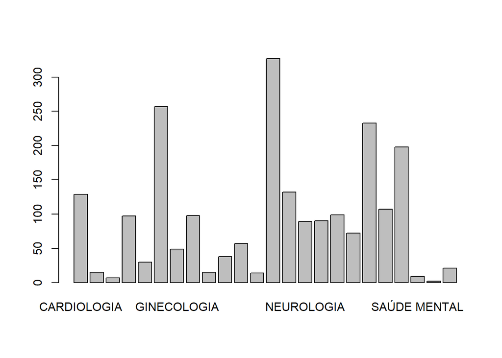

```r
# Plots
barplot(table(df$grupodiagnostico))
```

(idade)

Tipo de Variável: Quantitativa Discreta

```r
#Frequencia absoluta
table(df$idade)
```

```
##
##  9 10 11 12 13 14 15 16 17 18 19 20 21 22 23 24 25 26 27 28 29 30 31 32 33 34
##  1  2  4  2  3  5  4  6  5 22  9 13 12 17 28 21 22 22 16 19 10 19 16 18 19 19
## 35 36 37 38 39 40 41 42 43 44 45 46 47 48 49 50 51 52 53 54 55 56 57 58 59 60
## 28 27 21 22 35 24 29 27 22 21 30 39 35 54 62 46 38 33 39 48 56 41 41 29 43 43
## 61 62 63 64 65 66 67 68 69 70 71 72 73 74 75 76 77 78 79 80 81 82 83 84 85 86
## 39 27 47 45 43 26 33 23 32 42 31 35 34 30 35 37 26 37 48 33 24 30 37 18 31 24
## 87 88 89 90 91 94
## 18 17  6  7  2  1
```

```r
#Frequencia relativa
prop.table(table(df$idade))
```

```
##
##            9           10           11           12           13           14
## 0.0004576659 0.0009153318 0.0018306636 0.0009153318 0.0013729977 0.0022883295
##           15           16           17           18           19           20
## 0.0018306636 0.0027459954 0.0022883295 0.0100686499 0.0041189931 0.0059496568
##           21           22           23           24           25           26
## 0.0054919908 0.0077803204 0.0128146453 0.0096109840 0.0100686499 0.0100686499
##           27           28           29           30           31           32
## 0.0073226545 0.0086956522 0.0045766590 0.0086956522 0.0073226545 0.0082379863
##           33           34           35           36           37           38
## 0.0086956522 0.0086956522 0.0128146453 0.0123569794 0.0096109840 0.0100686499
##           39           40           41           42           43           44
## 0.0160183066 0.0109839817 0.0132723112 0.0123569794 0.0100686499 0.0096109840
##           45           46           47           48           49           50
## 0.0137299771 0.0178489703 0.0160183066 0.0247139588 0.0283752860 0.0210526316
##           51           52           53           54           55           56
## 0.0173913043 0.0151029748 0.0178489703 0.0219679634 0.0256292906 0.0187643021
##           57           58           59           60           61           62
## 0.0187643021 0.0132723112 0.0196796339 0.0196796339 0.0178489703 0.0123569794
##           63           64           65           66           67           68
## 0.0215102975 0.0205949657 0.0196796339 0.0118993135 0.0151029748 0.0105263158
##           69           70           71           72           73           74
## 0.0146453089 0.0192219680 0.0141876430 0.0160183066 0.0155606407 0.0137299771
##           75           76           77           78           79           80
## 0.0160183066 0.0169336384 0.0118993135 0.0169336384 0.0219679634 0.0151029748
##           81           82           83           84           85           86
## 0.0109839817 0.0137299771 0.0169336384 0.0082379863 0.0141876430 0.0109839817
##           87           88           89           90           91           94
## 0.0082379863 0.0077803204 0.0027459954 0.0032036613 0.0009153318 0.0004576659
```

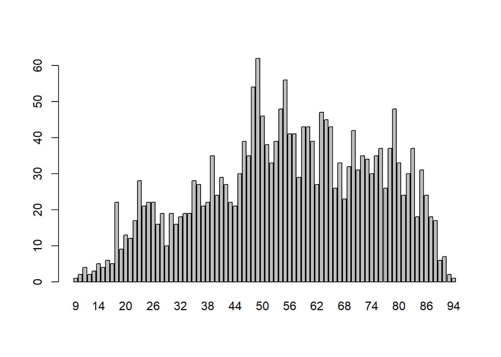

```r
# Bar Plots
barplot(table(df$idade))

library(ggplot2)
```

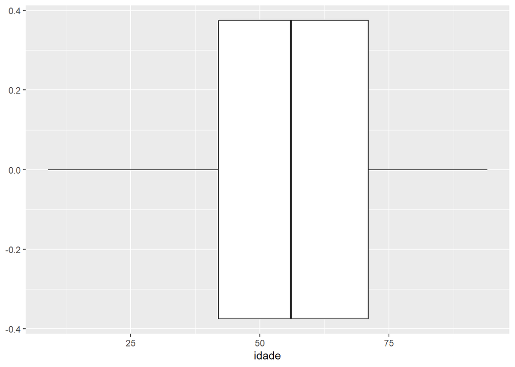

```r
ggplot(df, aes(x=idade))+
  geom_boxplot()
```

(diadasemana)

OBSERVAÇÕES: Observace menor frequencia de atendimento no final de semana e o maior atendimento no meio da semana.

Tipo de Variável: Qualitativa Nominal

```r
#Frequencia absoluta
table(df$diadasemana)
```

```
##
##   1   2   3   4   5   6   7
## 161 349 366 399 355 346 209
```

```r
#Frequencia relativa
prop.table(table(df$diadasemana))
```

```
##
##          1          2          3          4          5          6          7
## 0.07368421 0.15972540 0.16750572 0.18260870 0.16247140 0.15835240 0.09565217
```

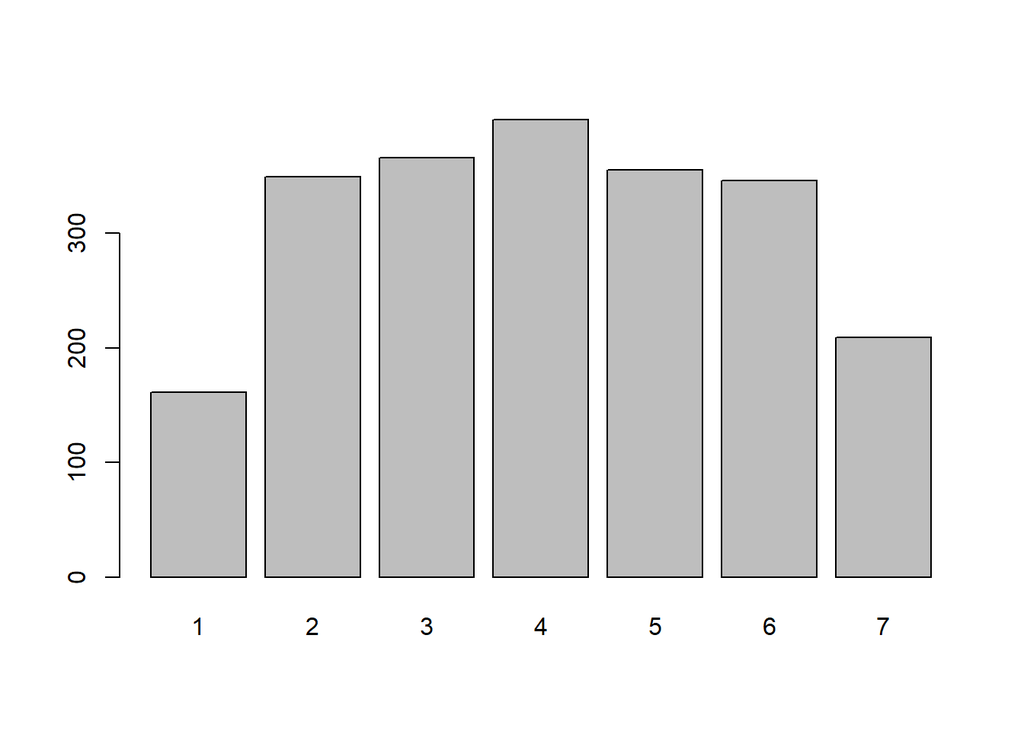

```r
# Bar Plots
barplot(table(df$diadasemana))
```

(dia)

OBSERVAÇÕES: A distribuição em dias do mês é bem distribuido, sem picos discrepantes.

Tipo de Variável: Qualitativa Nominal

```r
#Frequencia absoluta
table(df$dia)
```

```
##
##  1  2  3  4  5  6  7  8  9 10 11 12 13 14 15 16 17 18 19 20 21 22 23 24 25 26
## 65 68 65 86 67 81 73 62 66 78 92 75 65 68 56 73 73 83 68 84 71 67 75 88 66 67
## 27 28 29 30 31
## 71 72 53 62 45
```

```r
#Frequencia relativa
prop.table(table(df$dia))
```

```
##
##          1          2          3          4          5          6          7
## 0.02974828 0.03112128 0.02974828 0.03935927 0.03066362 0.03707094 0.03340961
##          8          9         10         11         12         13         14
## 0.02837529 0.03020595 0.03569794 0.04210526 0.03432494 0.02974828 0.03112128
##         15         16         17         18         19         20         21
## 0.02562929 0.03340961 0.03340961 0.03798627 0.03112128 0.03844394 0.03249428
##         22         23         24         25         26         27         28
## 0.03066362 0.03432494 0.04027460 0.03020595 0.03066362 0.03249428 0.03295195
##         29         30         31
## 0.02425629 0.02837529 0.02059497
```

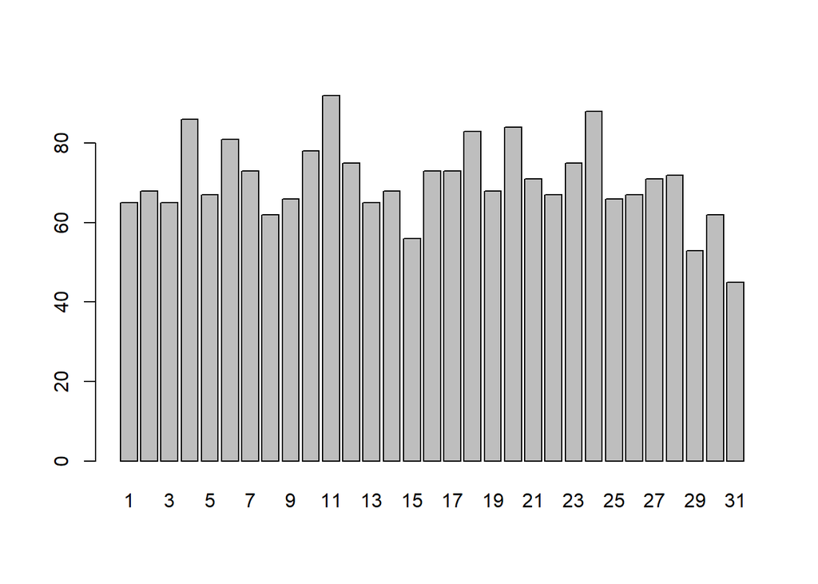

```r
# Bar Plots
barplot(table(df$dia))
```

(mes)

OBSERVAÇÕES: Observa-se uma maior frequencia no mês de março, podendo refletir fatores culturais e ambientais.

Tipo de Variável: Qualitativa Nominal

```r
#Frequencia absoluta
table(df$mes)
```

```
##
##   1   2   3   4   5   6   7   8   9  10  11  12
## 184 173 225 201 208 175 189 172 159 177 173 149
```

```r
#Frequencia relativa
prop.table(table(df$mes))
```

```
##
##          1          2          3          4          5          6          7
## 0.08421053 0.07917620 0.10297483 0.09199085 0.09519451 0.08009153 0.08649886
##          8          9         10         11         12
## 0.07871854 0.07276888 0.08100686 0.07917620 0.06819222
```

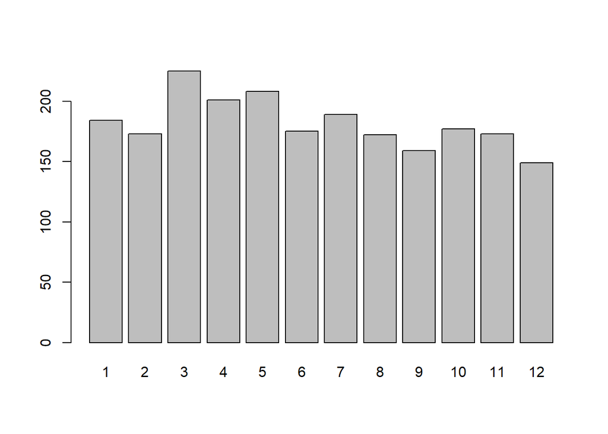

```r
# Bar Plots
barplot(table(df$mes))
```

(ano)

OBSERVAÇÕES: Observa-se uma crescente de atendimento com o passar dos anos e uma queda em 2016 que pode representar a amostra incompleta neste ano.

Tipo de Variável: Qualitativa Nominal

```r
#Frequencia absoluta
table(df$ano)
```

```
##
## 2000 2001 2002 2003 2004 2005 2006 2007 2008 2009 2010 2011 2012 2013 2014 2015
##   68  104   88   84   86   93  115  105  127  109  159  158  179  174  207  207
## 2016
##  122
```

```r
#Frequencia relativa
prop.table(table(df$ano))
```

```
##
##       2000       2001       2002       2003       2004       2005       2006
## 0.03112128 0.04759725 0.04027460 0.03844394 0.03935927 0.04256293 0.05263158
##       2007       2008       2009       2010       2011       2012       2013
## 0.04805492 0.05812357 0.04988558 0.07276888 0.07231121 0.08192220 0.07963387
##       2014       2015       2016
## 0.09473684 0.09473684 0.05583524
```

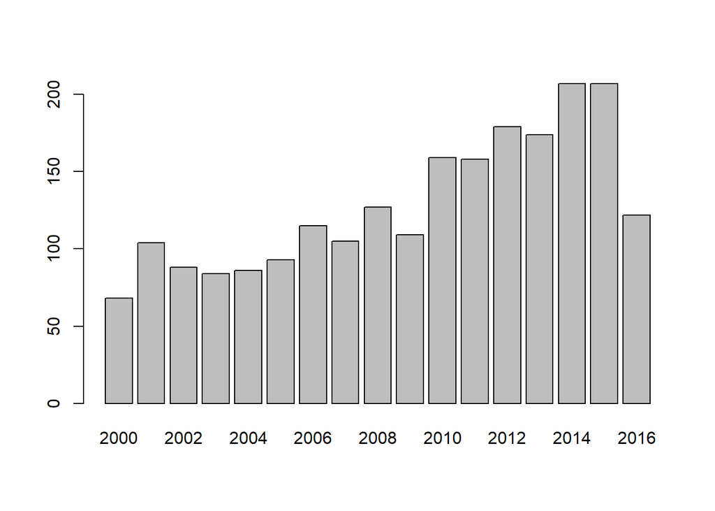

```r
# Bar Plots
barplot(table(df$ano))
```

(season)

OBSERVAÇÕES: Similar a distriuição mensal a distribuição trimestral reflete o comportamento.

Tipo de Variável: Qualitativa Nominal

```r
#Frequencia absoluta
table(df$season)
```

```
##
##   1   2   3   4
## 628 539 502 516
```

```r
#Frequencia relativa
prop.table(table(df$season))
```

```
##
##         1         2         3         4
## 0.2874142 0.2466819 0.2297483 0.2361556
```

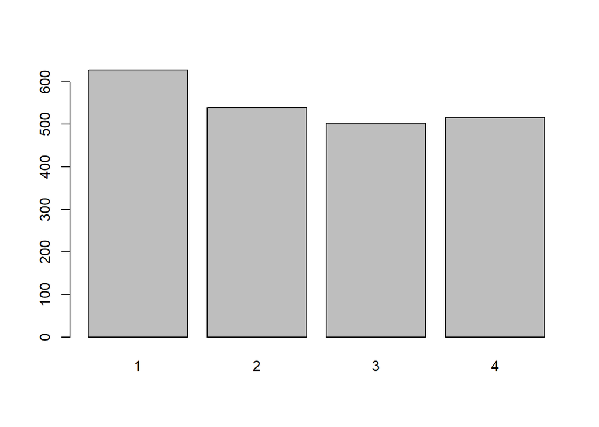

```r
# Bar Plots
barplot(table(df$season))
```

(internacao)

OBSERVAÇÕES: Analisando a tabela de frequencia e o grafico plotado vemos um comportamente esperado, onde existe muitas passagens que não converte em internação e uma pequena parcela que converte em interação, astante desalanceado.

Tipo de Variável: Qualitativa Nominal

```r
#Frequencia absoluta
table(df$internacao)
```

```
##
##    0    1
## 2010  175
```

```r
#Frequencia relativa
prop.table(table(df$internacao))
```

```
##
##          0          1
## 0.91990847 0.08009153
```

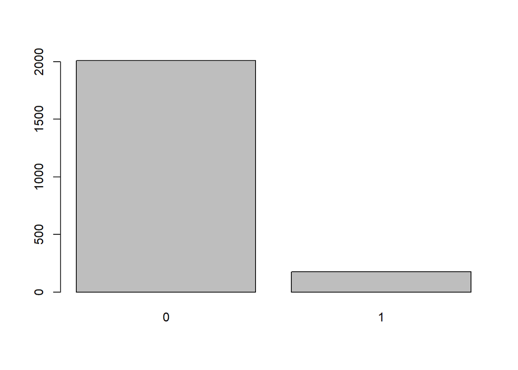

```r
# Bar Plots
barplot(table(df$internacao))
```

COMPLEMENTO DO ENTENDIMENTO DO PROLEMA DE NEGÓCIO

Utilizando o dataset complementar para captar medidas adicionais sobre o problema de negócio.

(cidade)

OBSERVAÇÕES: Cidade atual do paciente objeto da passagem, logo observamos que a cidade de São Paulo possui o maior numero de passagens.

Tipo de Variável: Qualitativa Nominal

```r
#Frequencia absoluta
table(dfC$cidade)
```

```
##
##                ARARAS               BARUERI              CAMPINAS
##                     2                   137                    14
##           CARAPICUIBA                 COTIA               ITAPEVI
##                     2                   101                     1
##               ITATIBA                   ITU           JOAO PESSOA
##                     3                     7                     1
##                OSASCO          RONDONOPOLIS   SANTANA DE PARNAIBA
##                    15                     1                    39
##           SANTO ANDRE SAO BERNARDO DO CAMPO   SAO JOSE DOS CAMPOS
##                     2                    11                     5
##             SAO PAULO       TABOAO DA SERRA              VALINHOS
##                  1783                    53                     8
```

```r
#Frequencia relativa
prop.table(table(dfC$cidade))
```

```
##
##                ARARAS               BARUERI              CAMPINAS
##          0.0009153318          0.0627002288          0.0064073227
##           CARAPICUIBA                 COTIA               ITAPEVI
##          0.0009153318          0.0462242563          0.0004576659
##               ITATIBA                   ITU           JOAO PESSOA
##          0.0013729977          0.0032036613          0.0004576659
##                OSASCO          RONDONOPOLIS   SANTANA DE PARNAIBA
##          0.0068649886          0.0004576659          0.0178489703
##           SANTO ANDRE SAO BERNARDO DO CAMPO   SAO JOSE DOS CAMPOS
##          0.0009153318          0.0050343249          0.0022883295
##             SAO PAULO       TABOAO DA SERRA              VALINHOS
##          0.8160183066          0.0242562929          0.0036613272
```

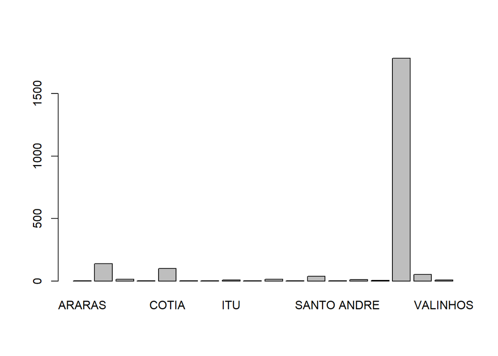

```r
# Bar Plots
barplot(table(dfC$cidade))
```

(estado)

OBSERVAÇÕES: Cidade atual do paciente objeto da passagem, logo observamos que a cidade SP possui o maior numero de passagens. O que corresponde com a localização do Hospital.

Tipo de Variável: Qualitativa Nominal

```r
#Frequencia absoluta
table(dfC$estado)
```

```
##
##   MT   PB   SP
##    1    1 2183
```

```r
#Frequencia relativa
prop.table(table(dfC$estado))
```

```
##
##           MT           PB           SP
## 0.0004576659 0.0004576659 0.9990846682
```

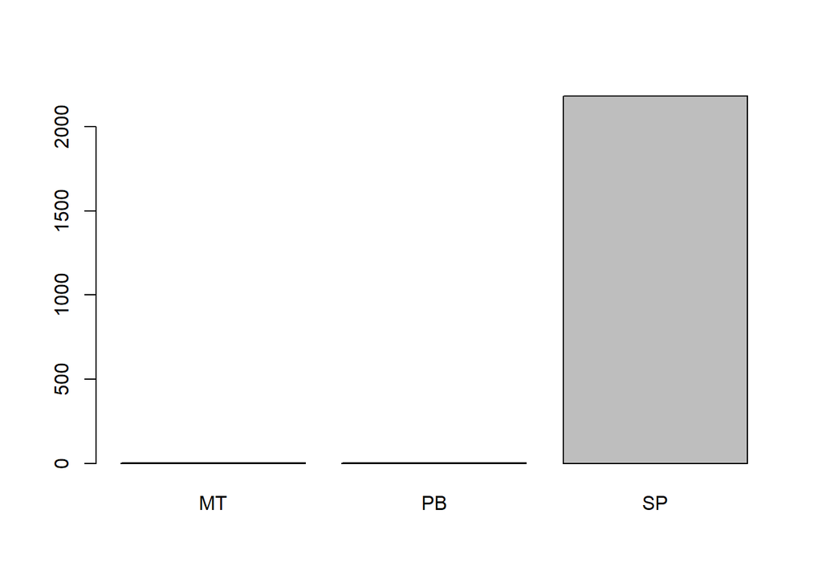

```r
# Bar Plots
barplot(table(dfC$estado))
```

(permanencia)

Tipo de Variável: Quantitativa Continua

```r
colunanumerica <- as.numeric(sub(",", ".", dfC$permanencia.dias.))

x = mean(colunanumerica)

cat(x, "Dias", " ") #Dias
```

```
## 0.375286 Dias
```

```r
y = x*24

cat(y, "Horas") #Horas
```

```
## 9.006865 Horas
```